## Reproducible Research Peer Assignment 1

This assignment makes use of data from a personal activity monitoring device. This device collects data at 5 minute intervals through out the day. The data consists of two months of data from an anonymous individual collected during the months of October and November, 2012 and include the number of steps taken in 5 minute intervals each day.

### Data Sets

The data for this assignment can be downloaded from the course web site: Dataset: Activity monitoring data (https://d396qusza40orc.cloudfront.net/repdata%2Fdata%2Factivity.zip)

The variables included in this dataset are: - steps: Number of steps taking in a 5-minute interval (missing values are coded as NA ) - date: The date on which the measurement was taken in YYYY-MM-DD format - interval: Identifier for the 5-minute interval in which measurement was taken

The dataset is stored in a comma-separated-value (CSV) file and there are a total of 17,568 observations in this dataset.

### Loading and preprocessing the data

Load packages

```r
library(plyr)
library(dplyr)
```

Read file

```r
setwd("~/Documents/Coursera_DS/Module5/Assignment1")
data <- read.csv("activity.csv")
```

### What is the mean total number of steps taken per day?

Group the data set by date

```r
group_day <- group_by(data,date)
data_day <- summarize(group_day, total_steps=sum(steps))
```

Make a histogram of the total number of steps taken each day

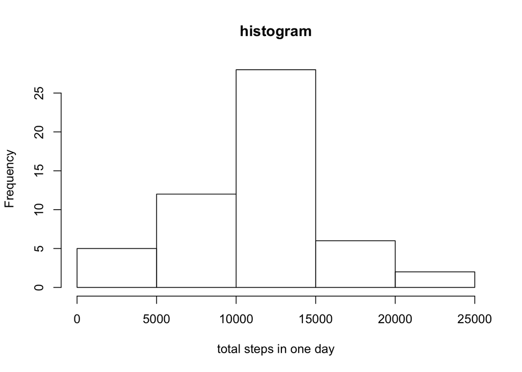

```r
hist(data_day$total_steps, main="histogram", xlab="total steps in one day")
```

Calculate and report the mean and median total number of steps per day

```r
mean <-mean(data_day$total_steps, na.rm=TRUE)
median <-median(data_day$total_steps, na.rm=TRUE)
```

The mean is 10766.19 and median is 10765.

### What is the average daily activity pattern?

To remove the NA values

```r
data_clean <- filter(data, !is.na(steps))
```

Group the data by 5-minute interval

```r
group_interval <-group_by(data_clean, interval)
data_interval <- summarize(group_interval, average_steps=mean(steps))
```

Make a time series plot of the 5-minute interval and average number of steps taken

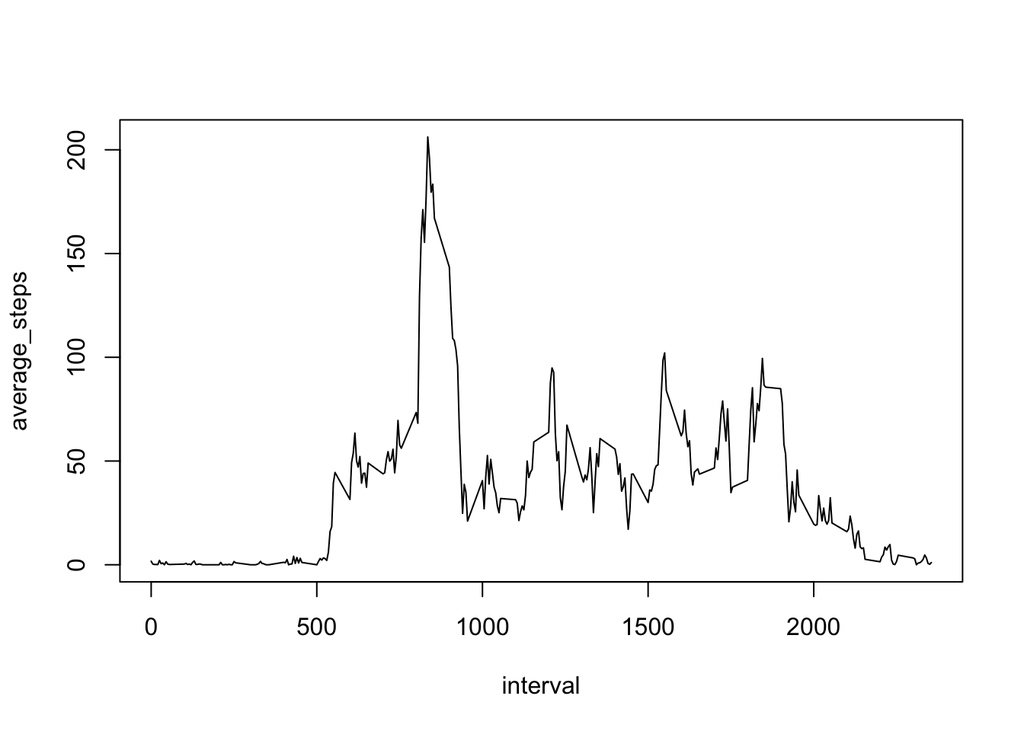

```r
plot(average_steps ~ interval, data_interval, type ="l")
```

Note: The x-axis reflect the HH:MM i.e. 0 refers to 00:00, 5 refers to 00:05 and so forth till 2355 refers to 23:55.

Order the data in descending and the maximum number of steps is on the top row

```r
data_intdesc <- arrange(data_interval, desc(average_steps))
head(data_intdesc)
```

```
## Source: local data frame [6 x 2]
##
##   interval average_steps
## 1      835      206.1698
## 2      840      195.9245
## 3      850      183.3962
## 4      845      179.5660
## 5      830      177.3019
## 6      820      171.1509
```

The time-interval of 08:35 contains the maximum number of steps.

### Imputing missing values

Calculate number of NAs

```r
na_steps <- is.na(data$steps)  ## Find the steps with NA
missing <- sum(na_steps)
```

The total number of missing values is 2304

Fill in missing values in the dataset using the average of 5-minutes interval

```r
join_data <- left_join(data,data_interval,by="interval")
join_data[na_steps,]$steps <- join_data[na_steps,]$average_steps
Newdata <- select(join_data, date, interval, steps)
```

Group the new dataset (removed NA) by date

```r
Newgroup_day <- group_by(Newdata,date)
Newdata_day <- summarize(Newgroup_day, total_steps=sum(steps))
```

Make a histogram of the total number of steps taken each day

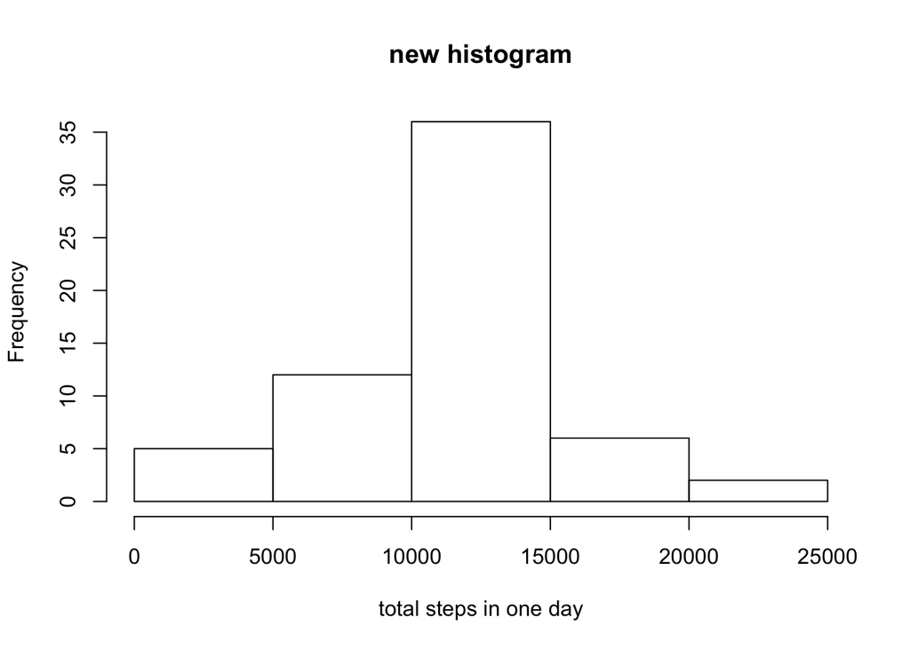

```r
hist(Newdata_day$total_steps, main="new histogram", xlab="total steps in one day")
```

Calculate and report the new mean and median total number of steps per day

```r
Newmean <-mean(Newdata_day$total_steps, na.rm=TRUE)
Newmedian <-median(Newdata_day$total_steps, na.rm=TRUE)
```

The new mean is 10766.19 and new median is 10766.19.

There is no significant difference between the old and new mean and median.

### Are there differences in activity patterns between weekdays and weekends?

Load required libraries

```r
library(lubridate)  ## for identifying weekday/weekend
```

```r
library(lattice) ## for plotting charts
```

Introduce a new factor variable to indicate whether the date is weekend

```r
data_addwk <- mutate(Newdata, weektime=factor(weekdays(ymd(date))
                                          %in% c('Saturday','Sunday')))
```

Group the data by weekday and weekend

```r
group_wk <- group_by(data_addwk, weektime, interval)
data_wk <- summarize(group_wk, steps = mean(steps))
```

Plot the average interval steps taken per day for weekday and weekend

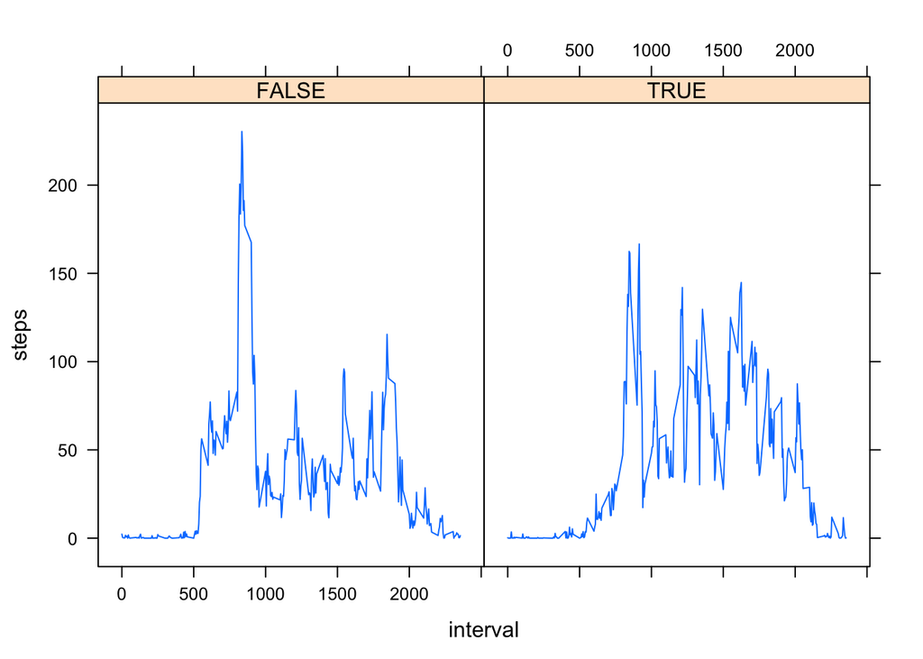

```r
chart <- xyplot(steps ~ interval | factor(weektime), data=data_wk, type='l')
print(chart)
```

Note: False refers to weekday, and True refers to weekend